# Phylogenetic comparative analysis of fungal secondary actins

Austin H. Patton

2023-10-12

```r
# Silently load R packages
library(phyr)
library(tidyverse)
library(ape)
library(ggtree)
library(phytools)
library(corHMM)
```

## 0.1 Data loading and preparation

### 0.1.1 FSA/HLA count data

```r
# Read in the fsa/hla data, again removing the mollusc
dat <- read_csv('../data/hla_fsa_dataset_for_tree_Austin.csv')
dat <- dat[-which(dat$Species == "Siphonaria sp. JEL0065"),]

# reformat, and also calculate the % Actins that are FSA
pdat <- data.frame(
  species = gsub(" ", "_", dat$Species),
  fsa_count = dat$fsa_count,
  hla_count = dat$hla_count,
  fsa_prop = dat$fsa_count / (dat$fsa_count + dat$hla_count),
  phylum = as.factor(dat$Phylum),
  phylum_simple = dat$Phylum
)

# Replace everything other than Ascomycota and Basidiomycota with "other",
# since the former two dominate the dataset
pdat$phylum_simple[-which(pdat$phylum %in% c('Ascomycota', 'Basidiomycota'))] <- 'Other'
pdat$phylum_simple <- factor(pdat$phylum_simple, levels = c('Other', 'Ascomycota', 'Basidiomycota'))
pdat$fsa_prop[which(!is.finite(pdat$fsa_prop))] <- 0
rownames(pdat) <-
  gsub(" ", "_", dat$Species)
```

### 0.1.2 Phylogenies

#### 0.1.2.1 timetree.org

First, read in the tree from timetree.org, and take a look

```r
# Read in the cladogram with species we want to retain
tree <- read.tree('../data/tree_for_hla_and_fsa.nwk')
tree <- drop.tip(tree, "Siphonaria_sp._JEL0065")

# Make sure the tree is ultrametric and fully bifurcating, with no 0-length branches
tree$edge.length <- tree$edge.length+0.00001
tree <- multi2di(tree)
tree <- force.ultrametric(tree, method = 'extend')
```

```
## *                          Note:                              *
## *    force.ultrametric does not include a formal method to    *
## *    ultrametricize a tree & should only be used to coerce    *
## *   a phylogeny that fails is.ultramtric due to rounding --   *
## *    not as a substitute for formal rate-smoothing methods.   *
```

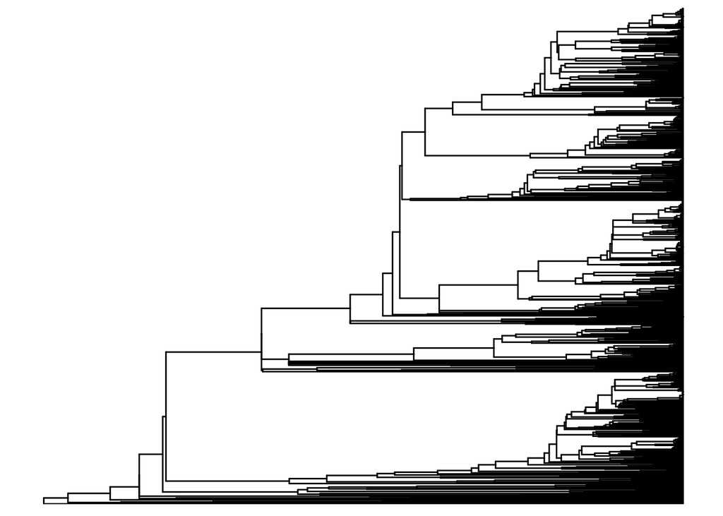

```r
# Take a look:
ggtree(tree)
```

#### 0.1.2.2 Torda et al. mushroom timetree

There are some features of the “raw” phylogeny from timetree.org that can cause some problems down the line. Let’s see if we can improve the dating slightly by using a more formally time-calibrated phylogeny of mushroom-forming fungal species to “congruify” the timetree.org phylogeny, making the latter’s branch-lengths more consistent with that of the former. This tree was obtained from the following dryad repo: https://datadryad.org/stash/dataset/doi:10.5061/dryad.gc2k9r9

```r
# Read in the time calibrated tree of mushroom forming fungi:
mush_tt <- read.tree('../data/r8s_kohler_etal_calibration_scheme1.tre')
mush_tt <- force.ultrametric(mush_tt, method = 'extend')
```

```
## *                          Note:                              *
## *    force.ultrametric does not include a formal method to    *
## *    ultrametricize a tree & should only be used to coerce    *
## *   a phylogeny that fails is.ultramtric due to rounding --   *
## *    not as a substitute for formal rate-smoothing methods.   *
```

```r
# rename tips in the mushroom time tree to match the timetree tree more closely:
corr_tiplabs <- sub("^(.*?_.*?)_.*", "\\1", tree$tip.label)
keep <- which(mush_tt$tip.label %in% sub("^(.*?_.*?)_.*", "\\1", tree$tip.label))
newnames <- tree$tip.label[which(sub("^(.*?_.*?)_.*", "\\1", tree$tip.label) %in% mush_tt$tip.label)]
newnames <- newnames[match(mush_tt$tip.label[keep], sub("^(.*?_.*?)_.*", "\\1", newnames))]
mush_tt$tip.label[keep] <- newnames

# Now, see what congruifying the timetree tree looks like:
cong_tree <-
  geiger::congruify.phylo(reference = mush_tt, target = tree,
                          scale = 'treePL', ncores = 7)

# Great. This might be a bit better behaved than the one from timetree.
# Use this one instead.
tree <- ladderize(cong_tree$phy)

# and again, make sure the tree is ultrametric and fully bifurcating, with no 0-length branches
tree$edge.length <- tree$edge.length+0.00001
tree <- multi2di(tree)
tree <- force.ultrametric(tree, method = 'extend')
```

```
## *                          Note:                              *
## *    force.ultrametric does not include a formal method to    *
## *    ultrametricize a tree & should only be used to coerce    *
## *   a phylogeny that fails is.ultramtric due to rounding --   *
## *    not as a substitute for formal rate-smoothing methods.   *
```

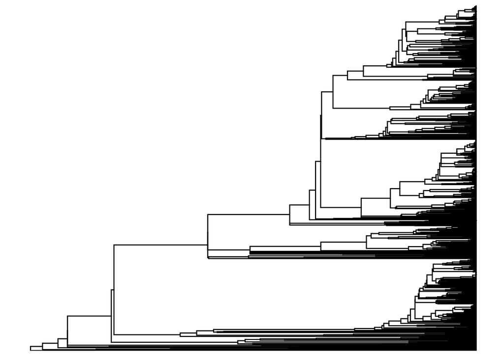

```r
# and take another look:
ggtree(tree)
```

#### 0.1.2.3 Visualizing phyla

Let’s visualize phyla on our phylogeny. Because phyla other that Basidiomycota and Ascomycota are poorly represented in our data, we collapse these different phyla into an “other” category.

```
## no colors provided. using the following legend:
##    Ascomycota Basidiomycota         Other
##       "black"     "#DF536B"     "#61D04F"
```

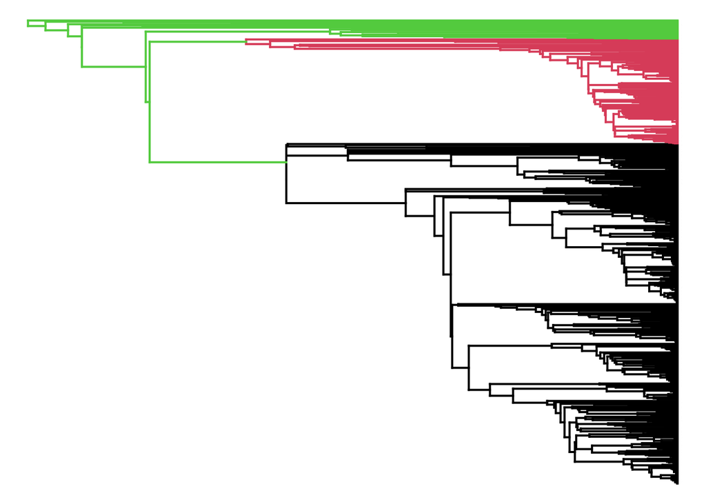

```r
# Get the common ancestor node for the two large phyla - Basidiomycota and Ascomycota - everything else will be treated in a third group:
phyla <- unique(pdat$phylum_simple)
phyla_mrca <- c()
for(p in 1:length(phyla)){
  phyla_mrca[p] <- getMRCA(tree, rownames(pdat)[which(pdat$phylum_simple == phyla[p])])
  names(phyla_mrca)[p] <- as.character(phyla[p])
}

phyla_tree <-
  paintSubTree(ladderize(tree), node = 1,
               state = 'Other',
               anc.state = 'Other',
               stem = T)
phyla_tree <-
  paintSubTree(phyla_tree, node = phyla_mrca[['Ascomycota']],
               state = 'Ascomycota',
               anc.state = 'Ascomycota')
phyla_tree <-
  paintSubTree(phyla_tree, node = phyla_mrca[['Basidiomycota']],
               state = 'Basidiomycota',
               anc.state = 'Basidiomycota')

# Now plot to see how this looks
plotSimmap(phyla_tree, fsize = 0.001)
```

## 0.2 Evolution of FSA/HLA count

Great. We’ve got our data prepared to analyze. Now let’s do some simple evolutionary analysis, beginning with something largely explorative, but still useful in refining our intuition regarding how FSA and HLA copy number evolve.

### 0.2.1 Ancestral gene count reconstruction

Specifically, we’ll first make some simplifying assumptions, fitting a model of continuous trait evolution to the count data, using this model to infer ancestral HLA/FSA gene counts along the phylogeny.

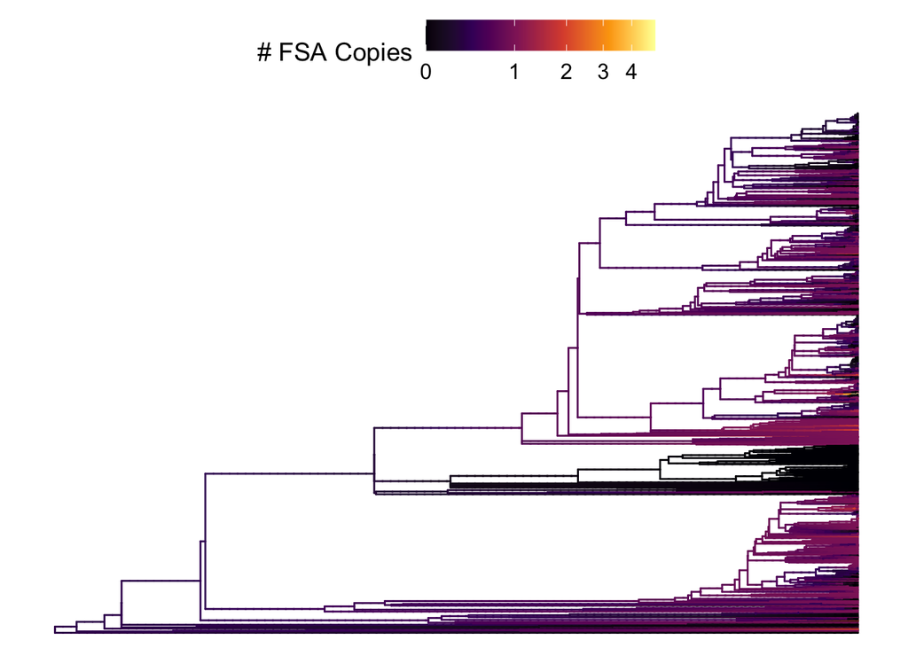

```r
# Begin by simply visualizing the trait on the tree with some inferred ancestral character states
fsa <- as.numeric(pdat$fsa_count)
hla <- as.numeric(pdat$hla_count)
prop <- as.numeric(pdat$fsa_prop)
names(fsa) <- rownames(pdat)
names(hla) <- rownames(pdat)
names(prop) <- rownames(pdat)
fsa_fit <- phytools::fastAnc(tree, log10(fsa+1))
hla_fit <- phytools::fastAnc(tree, log10(hla+1))
prop_fit <- phytools::fastAnc(tree, prop)

# Make a dataframe with trait values at the tips
td <-
  data.frame(
    node = nodeid(tree, names(fsa)),
    fsa_count = log10(fsa+1),
    hla_count = log10(hla+1),
    prop_fsa = prop)

# Make a dataframe with estimated trait values at the nodes
nd <- data.frame(node = names(fsa_fit),
                 fsa_count = c(fsa_fit),
                 hla_count = c(hla_fit),
                 prop_fsa = c(prop_fit))

# Combine these with the tree data for plotting with ggtree
d <- rbind(td, nd)
d$node <- as.numeric(d$node)

actin_tree <- full_join(tree, d, by = 'node')

fsa_tree_p <-
  ggtree(actin_tree,
         aes(color = fsa_count),
         ladderize = TRUE, continuous = "color", size = 0.5) +
  scale_color_viridis_c(option = "inferno",
                        name = "# FSA Copies",
                        breaks = c(0, 0.30103, 0.4771213,
                                   0.60206, 0.69897),
                        labels = c(0, 1, 2, 3, 4)) +
  theme(legend.position = 'top',
        legend.text = element_text(size = 12),
        legend.key.width = unit(0.9,"cm"),
        legend.title = element_text(size = 14)) +
  coord_cartesian(clip="off")

hla_tree_p <-
  ggtree(actin_tree,
         aes(color = hla_count),
         ladderize = TRUE, continuous = "color", size = 0.5) +
  scale_color_viridis_c(option = "inferno",
                        name = "# HLA Copies",
                        breaks = c(0, 0.30103, 0.4771213,
                                   0.60206, 0.69897),
                        labels = c(0, 1, 2, 3, 4)) +
  theme(legend.position = 'top',
        legend.text = element_text(size = 12),
        legend.key.width = unit(0.9,"cm"),
        legend.title = element_text(size = 14)) +
  coord_cartesian(clip="off")
prop_fsa_tree_p <-
  ggtree(actin_tree,
         aes(color = prop_fsa),
         ladderize = TRUE, continuous = "color", size = 0.5) +
  scale_color_viridis_c(option = "inferno",
                        name = "Prop. Actins FSA") +
  theme(legend.position = 'top',
        legend.text = element_text(size = 12),
        legend.key.width = unit(0.9,"cm"),
        legend.title = element_text(size = 14)) +
  coord_cartesian(clip="off")

actin_plt <- cowplot::plot_grid(fsa_tree_p, hla_tree_p, prop_fsa_tree_p, nrow = 1)

# Create the plot directory if we haven't already:
dir.create('plots', showWarnings = F)

# And save this to PDF.
ggsave(actin_plt, file = '../plots/fsa_hla_actin_ancestral_reconstructions.pdf',
       height = 8, width = 12)

# Let's quick visualize below:
fsa_tree_p
```

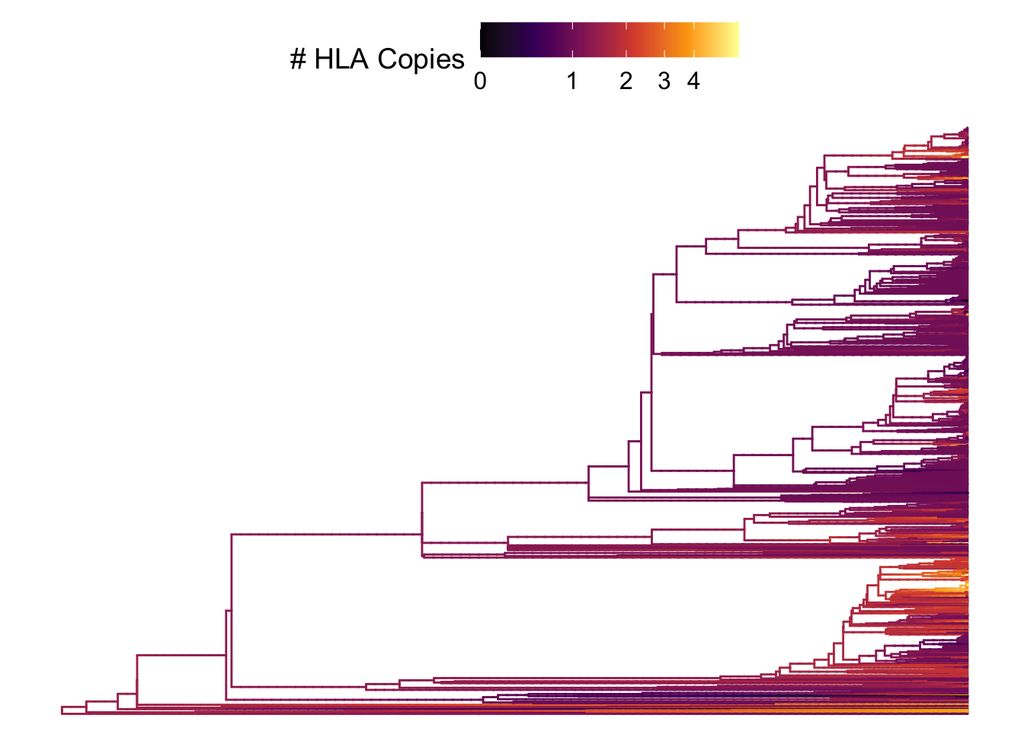

```r
hla_tree_p
```

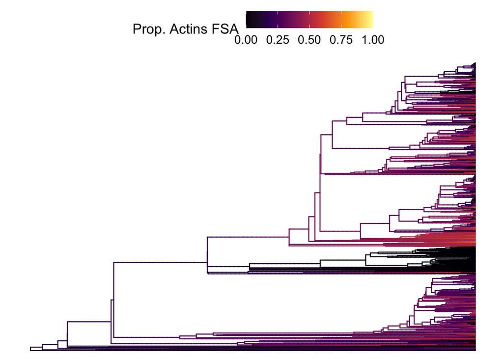

```r
prop_fsa_tree_p
```

### 0.2.2 (Phylogenetic) linear models

Great, now formally assess the extent to which FSA counts are predicted by the counts of HLA. We will accomplish this using generalized linear models, and will explore the extent to which accounting for evolutionary non-independence of species and their traits may impact results.

#### 0.2.2.1 Univariate: FSA ~ HLA

```r
# First, a simple glm, not accounting for phylogeny
fit_gaus <- glm(fsa_count ~ hla_count, data = pdat)

# Then, one that explicitly accounts for phylogeny:
fit_pgaus <- pglmm_compare(fsa_count ~ hla_count, data = pdat, phy = tree)
```

```
## 'as(<matrix>, "dgTMatrix")' is deprecated.
## Use 'as(as(as(., "dMatrix"), "generalMatrix"), "TsparseMatrix")' instead.
## See help("Deprecated") and help("Matrix-deprecated").
```

```r
# Note, we can fit models using either a poisson or binomial distribution.
# Poisson is useful for count data, but assumes the mean and variance of the
# distribution is the same, something that is not true of our data.
# Binomial distributions are useful for binary success/failure type data.
fit_ppois <- pglmm_compare(fsa_count ~ hla_count, data = pdat, phy = tree, family = "poisson")
# As you can see, the poisson fits the data more poorly than does the gaussian.
# Consequently, we just proceed with the gaussian
summary(fit_pgaus)
```

```
## Linear mixed model fit by restricted maximum likelihood
##
## Call:fsa_count ~ hla_count
##
## logLik    AIC    BIC
## -559.7 1127.4 1141.3
##
## Phylogenetic random effects variance (s2):
##          Variance Std.Dev
## s2       0.000827 0.02876
## residual 0.161620 0.40202
##
## Fixed effects:
##                Value Std.Error Zscore    Pvalue
## (Intercept) 0.378914  0.332360 1.1401    0.2543
## hla_count   0.098208  0.021971 4.4699 7.824e-06 ***
## ---
## Signif. codes:  0 '***' 0.001 '**' 0.01 '*' 0.05 '.' 0.1 ' ' 1
```

```r
summary(fit_ppois)
```

```
## Generalized linear mixed model for poisson data fit by restricted maximum likelihood
##
## Call:fsa_count ~ hla_count
##
## logLik    AIC    BIC
## -678.4 1364.8 1378.6
##
## Phylogenetic random effects variance (s2):
##     Variance Std.Dev
## s2 0.0006084 0.02466
##
## Fixed effects:
##                 Value Std.Error  Zscore  Pvalue
## (Intercept) -0.868575  0.370520 -2.3442 0.01907 *
## hla_count    0.117139  0.046681  2.5094 0.01209 *
## ---
## Signif. codes:  0 '***' 0.001 '**' 0.01 '*' 0.05 '.' 0.1 ' ' 1
```

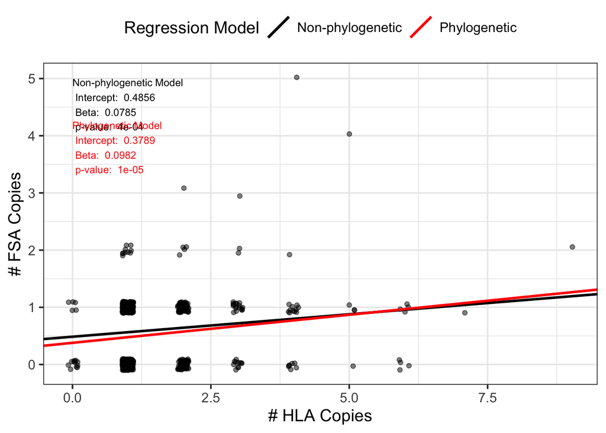

```r
# Now plot this, adding both regression
# slopes to show the effect of accounting for phylogeny and include
# model coefficients and p-values

# Define the intercept, beta (slope), and p-value text for each model
non_phylo_text <- paste("Non-phylogenetic Model\n",
                        "Intercept: ", round(fit_gaus$coefficients[1], 4), "\n",
                        "Beta: ", round(fit_gaus$coefficients[2], 4), "\n",
                        "p-value: ", round(summary(fit_gaus)$coefficients[2,4], 5))

phylo_text <- paste("Phylogenetic Model\n",
                    "Intercept: ", round(fit_pgaus$B[1], 4), "\n",
                    "Beta: ", round(fit_pgaus$B[2], 4), "\n",
                    "p-value: ", round(fit_pgaus$B.pvalue[2], 5))

fsa_hsa_corrplot <-
  ggplot(data = pdat, aes(y = fsa_count, x = hla_count)) +
  geom_point(alpha = 0.5,
             position = position_jitter(width = 0.1,
                                        height = 0.1)) +
  geom_abline(aes(intercept = fit_gaus$coefficients[1], slope = fit_gaus$coefficients[2], color='Non-phylogenetic'), size = 1) +
  geom_abline(aes(intercept = fit_pgaus$B[1], slope = fit_pgaus$B[2], color='Phylogenetic'), size = 1) +
  scale_color_manual(name='Regression Model',
                     values=c('Non-phylogenetic'='black',
                              'Phylogenetic'='red')) +
  theme_bw(base_size = 14) +
  xlab('# HLA Copies') +
  ylab('# FSA Copies') +
  annotate("text", x = min(pdat$hla_count), y = max(pdat$fsa_count), hjust = 0, vjust = 1,
           label = non_phylo_text, color = "black", size = 3) +
  annotate("text", x = min(pdat$hla_count), y = max(pdat$fsa_count) - 0.75, hjust = 0, vjust = 1,
           label = phylo_text, color = "red", size = 3) +
  theme(legend.position = 'top')
# Save this
ggsave(fsa_hsa_corrplot, file = '../plots/fsa_hsa_correlation_plt.pdf', height = 7, width = 7)

# And visualize below:
fsa_hsa_corrplot
```

```r
# Save fitted models:
fitted_univar_mods <-
  list(nonphy_gaus = fit_gaus,
       phylog_gaus = fit_pgaus,
       plylog_pois = fit_ppois)
saveRDS(fitted_univar_mods, file = "../models/glms_univar_count.Rds")
```